# 시계열 데이터 프레임 (xts: Extensible Time Series)과 quantmod 패키지

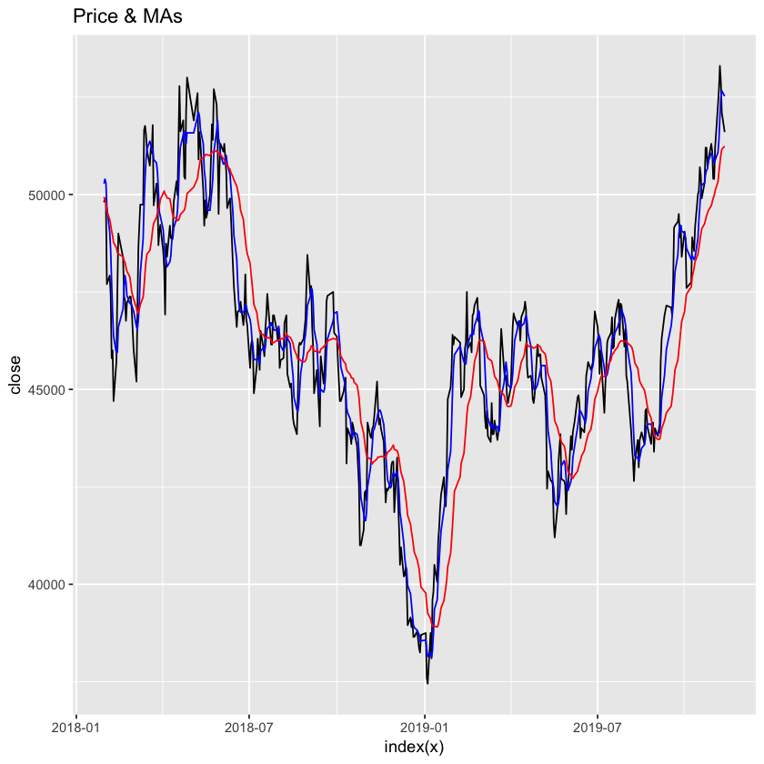

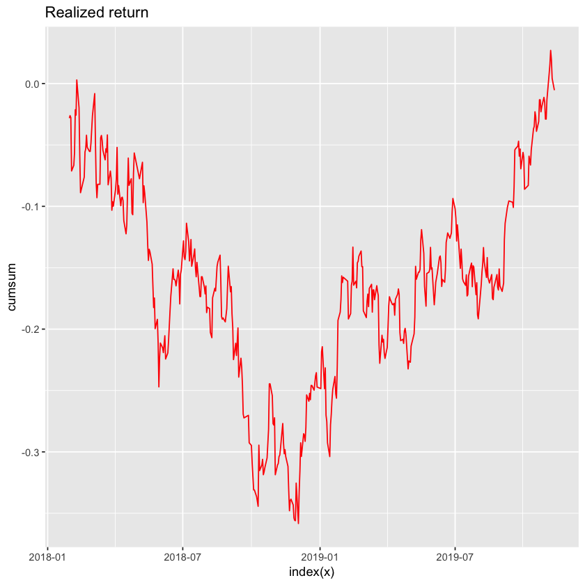

```r
r <- goldenCross(p['2018::'], 5, 20, chart=T)
```

- 단기, 장기 이동평균 기간 설정에 따라 성과가 다르게 나타나므로 최적 이동평균 기간을 설정해 봄
- GoldenCross.R에 정의된 optimize 함수를 이용하여 설정된 검색 기간 내에서 누적 수익률이 최대가 되거나, 누적 수익률의 표준편차가 최소가 되거나, Sharp Ratio가 최대가 되는 이동평균 기간을 찾아 봄
- 최적 이동평균 기간을 적용하여 성과를 다시 분석함 -> 분석 기간과 적용 기간은 달라야 함 (K-Fold Cross Validation test 참고)

```r
opt <- optimize(p['2018-01-01::2019-10-30'], 5, 40, 15, 120)
```

```r
opt
```

|  | ShrtMA | LongMA | Last | Stdev | Sharp | Remark |
| --- | --- | --- | --- | --- | --- | --- |
| 1 | 5 | 20 | -0.01379332 | 0.01600225 | -0.8619614 | Max return |
| 1160 | 14 | 99 | -0.01379332 | 0.01487616 | -0.9272101 | Min stdev |
| 3 | 5 | 20 | -0.01379332 | 0.01600225 | -0.8619614 | Max sharp ratio |

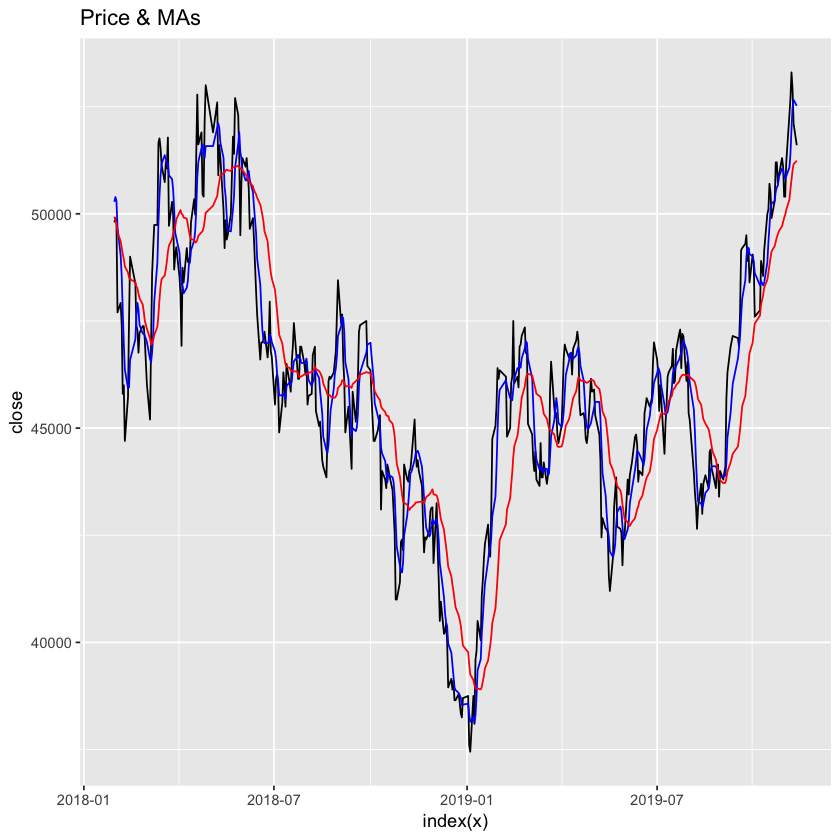

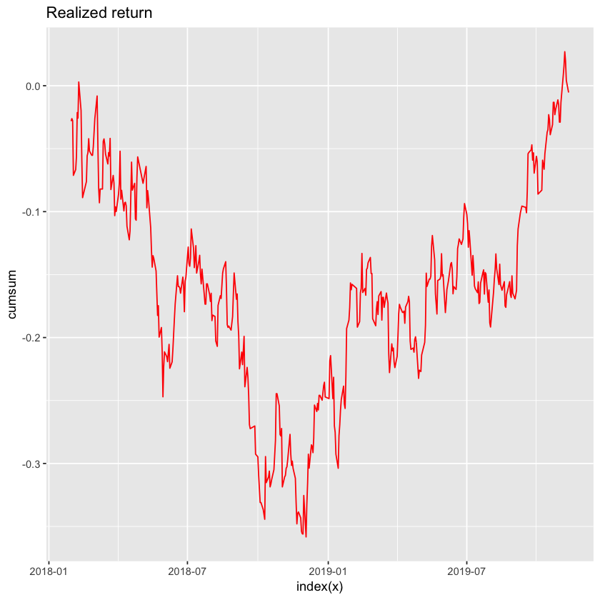

```r
# 2018 이후에 최적 기간을 적용함
r <- goldenCross(p['2018-01-01::'], 5, 20, chart=T)
```

-1.25867677210608e-05

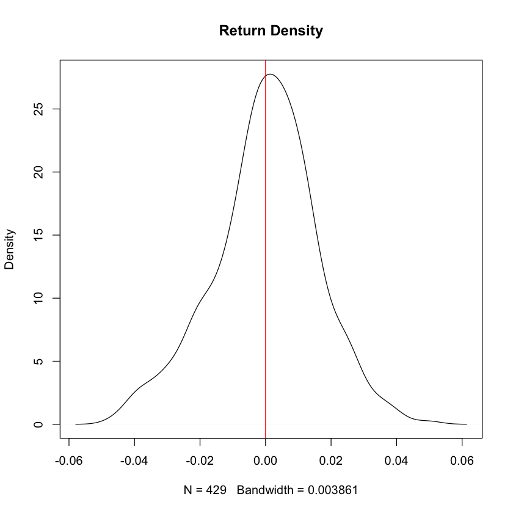

```r
plot(density(r), main="Return Density")
abline(v=mean(r), col='red')
mean(r)
```

# 시계열의 평활화: 단순이동평균(SMA), Kernel Regression, Spline

- Kernel Regression 방식은 평활점을 계산하는 시점에 정규분포를 적용해서 인근 시계열 데이터의 가중치를 다르게 적용하여 가중 평균을 계산한 방식임. 정규분포의 중심부분에는 높은 가중치를 부여하고, 좌, 우로 갈수록 점차 가중치를 낮게 부여
- Spline은 인접한 두 점을 다항식으로 잇고 두 개의 다항 곡선을 서로 미분 가능하도록(Smooth한 곡선이 되도록) 잇는 원리
- Kernel과 Spline은 후행성이 없음. 그러나 이것은 과거 시점에서 미래의 데이터를 이용하기 때문임. 현재 시점에서 미래 데이터는 이용할 수 없음. -> 과거 데이터만으로 후행성이 없는 평활선을 찾는 것은 불가함

```r
library(quantmod)
source('1.CollectData.R')
```

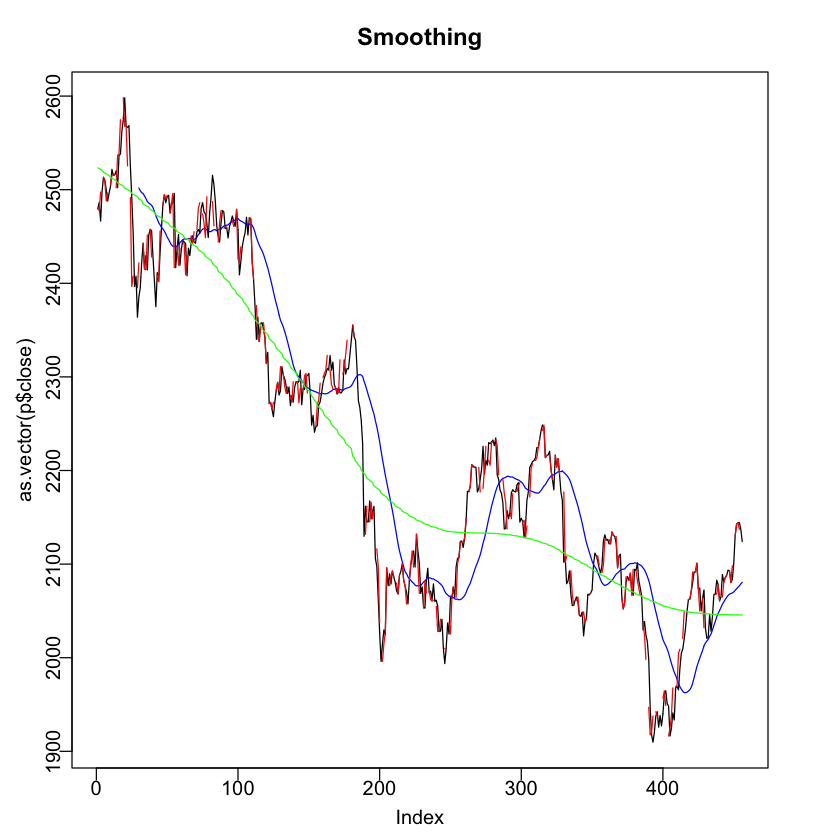

```r
p <- getKospi(from='2018-01-01')

# 평활화 (Smoothing), 단순 이동평균 (SMA)
p$sma <- SMA(p$close, n=30)

# Kernel Regression 평활화
# ksmooth는 list를 반환함 --> 데이터 프레임으로 변환
k <- as.data.frame(ksmooth(time(p), p$close, 'normal', bandwidth=0.5))
p$kernel <- as.xts(k$y, order.by=index(p))

# Spline 평활화
# Spline은 직접 데이터 프레임으로 변환 안됨, $y로 y요소만 변환
k <- as.data.frame(smooth.spline(time(p), p$close, spar=1)$y)
p$spline <- as.xts(k, order.by=index(p))

par(mar=c(3, 3, 3, 3), mgp=c(1.5, 0.3, 0))
plot(as.vector(p$close), type='l', main='Smoothing')
lines(as.vector(p$sma), col='blue')
lines(as.vector(p$kernel), col='red')
lines(as.vector(p$spline), col='green')
```